# Analyze_ab_test_results_notebook

## Analyze A/B Test Results

- Introduction
- Part I - Probability
- Part II - A/B Test
- Part III - Regression

### Introduction

For this project, we will be working to understand the results of an A/B test run by an e-commerce website. Our goal is to work through the data provided by the ab_data.csv to help the company understand if they should implement the new page, keep the old page, or perhaps run the experiment longer to make their decision.

#### Part I - Probability

Import the libraries.

```python
import pandas as pd
import numpy as np
import random
import matplotlib.pyplot as plt
%matplotlib inline
#We are setting the seed to assure you get the same answers on quizzes as we set up
random.seed(42)
```

Reading the dataset taking a look at the top few rows

```python
# Reading dataset ab_data.csv and looking at the top few rows
df = pd.read_csv('ab_data.csv')
df.head()
```

|  | user_id | timestamp | group | landing_page | converted |
| --- | --- | --- | --- | --- | --- |
| 0 | 851104 | 2017-01-21 22:11:48.556739 | control | old_page | 0 |
| 1 | 804228 | 2017-01-12 08:01:45.159739 | control | old_page | 0 |
| 2 | 661590 | 2017-01-11 16:55:06.154213 | treatment | new_page | 0 |
| 3 | 853541 | 2017-01-08 18:28:03.143765 | treatment | new_page | 0 |
| 4 | 864975 | 2017-01-21 01:52:26.210827 | control | old_page | 1 |

Finding the number of rows in the dataset.

```python
# Find the number of rows throught the function shape
# that returns the matrix's dimension, an getting the 0 position is the row number
df.shape[0]
```

```
294478
```

The number of unique users in the dataset.

```python
# Getting the number of unique users throught nunique function
df.nunique()
```

```
user_id         290584
timestamp       294478
group                2
landing_page         2
converted            2
dtype: int64
```

The proportion of users converted.

```python
# Getting the unique values of converted user per unique value of users
# to get the proportionf of users converted
df.query('converted == 1')['user_id'].nunique() / df['user_id'].nunique()
```

```
0.12104245244060237
```

The number of times the `new_page` and `treatment` don't match.

```python
# Using query function to find the number of times
# the new_page and treatment don't match.
df.query("group == 'treatment' and landing_page == 'old_page'").shape[0] + df.query("group == 'control' and landing_page == 'new_page'").shape[0]
```

```
3893
```

Verifying whether any of the rows have missing values

```python
# Using the info function we can get the number of non-null object
# of each column
df.info()
```

```
<class 'pandas.core.frame.DataFrame'>
RangeIndex: 294478 entries, 0 to 294477
Data columns (total 5 columns):
user_id         294478 non-null int64
timestamp       294478 non-null object
group           294478 non-null object
landing_page    294478 non-null object
converted       294478 non-null int64
dtypes: int64(2), object(3)
memory usage: 11.2+ MB
```

For the rows where **treatment** does not match with **new_page** or **control** does not match with **old_page**, we cannot be sure if this row truly received the new or old page.

Creating a new dataset that meets the specifications to use to figure out how we should handle these rows.

```python
# Creating a new  dataset to match the quiz sprecifications
df2 = df.query("group == 'treatment' and landing_page == 'new_page'")
df2 = df2.append(df.query("group == 'control' and landing_page == 'old_page'"))
```

```python
# Double Check all of the correct rows were removed - this should be 0
df2[((df2['group'] == 'treatment') == (df2['landing_page'] == 'new_page')) == False].shape[0]
```

```
0
```

Amount of unique **user_id**s in **df2**

```python
# Using nunique function we get the number of unique values of user_i
df2['user_id'].nunique()
```

```
290584
```

Finding the one **user_id** repeated in **df2**.

```python
# Using function duplicated we get the value True
# and indexing into df2 we get the row that is duplicated
df2[df2['user_id'].duplicated()]
```

|  | user_id | timestamp | group | landing_page | converted |
| --- | --- | --- | --- | --- | --- |
| 2893 | 773192 | 2017-01-14 02:55:59.590927 | treatment | new_page | 0 |

Finding the row information for the repeat **user_id**

```python
# Find the rows that has user_id equal to 773192
df2.query('user_id == 773192')
```

|  | user_id | timestamp | group | landing_page | converted |
| --- | --- | --- | --- | --- | --- |
| 1899 | 773192 | 2017-01-09 05:37:58.781806 | treatment | new_page | 0 |
| 2893 | 773192 | 2017-01-14 02:55:59.590927 | treatment | new_page | 0 |

Removing **one** of the rows with the duplicate **user_id** and calculating probaility and conditional probability

```python
# use df drop function to remove user 2893 line
df2.drop(2893, axis=0, inplace =True)
```

```python
# Calculating the probability of an individual converting
# regardless of the page they receive
df2.query('converted == 1').shape[0] / df2.shape[0]
```

```
0.11959708724499628
```

```python
# Calculating the probability of an individual to convert
# given that individual was in the control group
p_control = df2.query("converted == 1 and group == 'control'").shape[0] / df2.query("group == 'control'").shape[0]
p_control
```

```
0.1203863045004612
```

```python
# Calculating the probability of an individual to convert
# given that individual was in the treatment group
p_treatment = df2.query("converted == 1 and group == 'treatment'").shape[0] / df2.query("group == 'treatment'").shape[0]
p_treatment
```

```
0.11880806551510564
```

```python
# Calculating the probability of the individual receive the new_page
df2.query("landing_page == 'new_page'").shape[0] / df2.shape[0]
```

```
0.5000619442226688
```

**Response:** There isn't sufficiente evidence to conclude that the new page leads to more conversion. First of all, The probability calculated sugest that the new page and old page has a similar or close probability of convertion. It is not sufficiente data, bacause we don't know whether it happen consistently for a certain amount of time that assures us to considere one page better than another. Another revelant fact is that one individual is different from other and an individual can take more time to accept changes than other, so it can bies the result.

### Part II - A/B Test

Because of the time stamp associated with each event, we could technically run a hypothesis test continuously as each observation was observed.

However, then the hard question is do you stop as soon as one page is considered significantly better than another or does it need to happen consistently for a certain amount of time? How long do you run to render a decision that neither page is better than another?

Representing the null and alternative hypotheses and verifying if one page is considered significantly better than another or does it need to happen consistently for a certain amount of time.

**Response:** $$H_0: p_{new} - p_{old} \le 0$$ $$H_1: p_{new} - p_{old} \gt 0$$

Calculating the **conversion rate** for $p_{new}$ under the null

```python
# Assuming the p_new is equal to the converted rate in ab_data.csv
# regardless of the page.
p_new = df2.query('converted == 1').shape[0] / df2.shape[0]
p_new
```

```
0.11959708724499628
```

Calculating the **conversion rate** for $p_{old}$ under the null

```python
# Assuming the p_old is equal to the converted rate in ab_data.csv
# regardless of the page.
p_old = df2.query('converted == 1').shape[0] / df2.shape[0]
p_old
```

```
0.11959708724499628
```

Calculating $n_{new}$, the number of individuals in the treatment group

```python
# Getting the number of indivifuals in the treatmenr group
n_new = df2.query("group == 'treatment'").shape[0]
n_new
```

```
145310
```

```python
# Getting the number of indivifuals in the control group
n_old = df2.query("group == 'control'").shape[0]
n_old
```

```
145274
```

Simulating $n_{new}$ transactions with a conversion rate of $p_{new}$ under the null.

```python
# Simulation transactions with size of n_new ans a conversion rate of p_new
new_page_converted = np.random.binomial(1,p_new,n_new)
new_page_converted
```

```
array([0, 1, 1, ..., 0, 0, 0])
```

Simulating $n_{old}$ transactions with a conversion rate of $p_{old}$ under the null.

```python
# Simulation transactions with size of n_old ans a conversion rate of p_old
old_page_converted = np.random.binomial(1,p_old,n_old)
old_page_converted
```

```
array([0, 0, 0, ..., 0, 1, 0])
```

Finding $p_{new}$ - $p_{old}$ for our simulated values

```python
# Simulating the diff between p_new and p_old
new_page_converted.mean() - old_page_converted.mean()
```

```
0.0016225135664632295
```

Creating 10,000 $p_{new}$ - $p_{old}$ values using the same simulation process used in parts above.

```python
# Create sampling distribution for difference in completion rates
# with boostrapping
p_diffs = []

for _ in range(10000):
    b_page_new = np.random.binomial(1,p_new,n_new)
    b_page_old = np.random.binomial(1,p_old,n_old)
    diff = b_page_new.mean() - b_page_old.mean()
    p_diffs.append(diff)
```

Plotting a histogram of the **p_diffs**.

```python
# convert to numpy array
p_diffs = np.array(p_diffs)
```

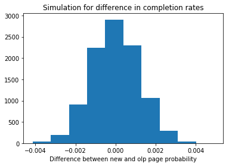

```python
# plot distribution using pyplot function hist
plt.hist(p_diffs);
plt.title("Simulation for difference in completion rates");
plt.xlabel("Difference between new and olp page probability");
```

Calculating the proportion of the **p_diffs** are greater than the actual difference observed in **ab_data.csv**

```python
# Diff between p_control (probability of an individual to convert
# given that individual was in the control group) and p_treatment (probability of an individual to convert
# given that individual was in the treatment group)
obs_diff = p_treatment - p_control
obs_diff
```

```
-0.0015782389853555567
```

```python
# Proportion of the p_diffs greater than the actual difference observed
# It is called p_value
(p_diffs > obs_diff).mean()
```

```
0.90800000000000003
```

**Response:** In the first part we have computed the value of p_value. This value represents the probability of observing your statistic if the null hypothesis is true.

Using a built-in to achieve similar results.

```python
import statsmodels.api as sm

# Calculating the number of conversions for each page
convert_old = df2.query("converted == 1 and landing_page == 'old_page'").shape[0]
convert_new = df2.query("converted == 1 and landing_page == 'new_page'").shape[0]

# Calculaing the number of rows associated with the old page and new pages
n_old = df2.query("landing_page == 'old_page'").shape[0]
n_new = df2.query("landing_page == 'new_page'").shape[0]
```

Using `stats.proportions_ztest` to compute our test statistic and p-value.

```python
# Computing test statistic using sm.stats.proportions_ztest function, that returns
# the z_score and p_value
z_score, p_value = sm.stats.proportions_ztest([convert_old,convert_new],[n_old,n_new], alternative='smaller')
z_score, p_value
```

```
(1.3109241984234394, 0.90505831275902449)
```

**Response:** The values of z_score and p_value means that we fail to reject the null hypotesis. When we get a value of p_value $\gt \alpha$ (0.05), its suggest that we fail to reject the null hypotesis and using a 95% confidence level the critical z_score values are -1.96 and +1.96 standard deviations, we found a value between -1.96 and +1.96, so its suggest that our p_value will be largen than the $\alpha$ which correspond with the p_value found. The results found in first part are in agreement with the values found in the second part (Built-in simulation), because using both methods we fail to reject the null hypothesis.